# Size class small comparisons

Renata Diaz 2020-08-05

##### Results for small (FIA sized) communities

Here are the results when we try to tell whether FIA communities differ qualitatively from similarly-sized communities from other datasets…

###### Small sites

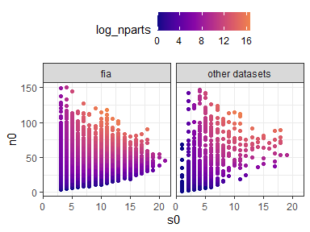

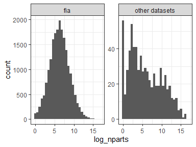

Having played around with the shiny app (size_comparisons), here are some static plots that I think are faithful to what I glean from tinkering with cutoffs.

##### Trivially small

For a range of about 1-300 elements in the FS, I wouldn’t argue for any kind of detectable pattern in any of the results:

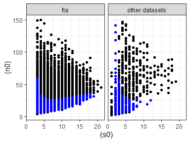

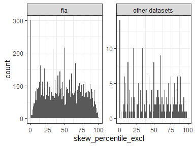

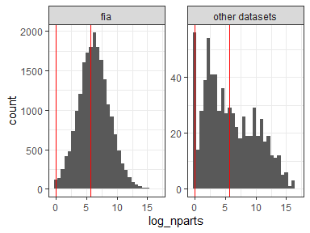

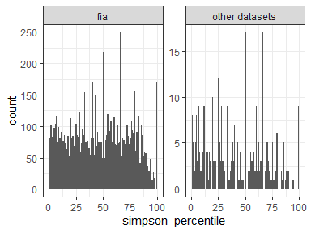

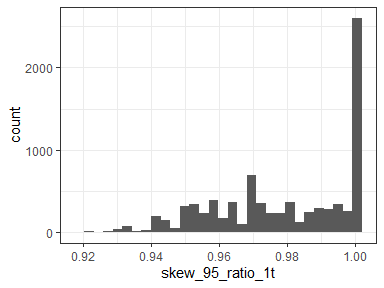

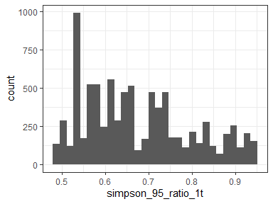

| fia_yn | prop_skew_high | nskew_sites |
| --- | --- | --- |
| fia | 0.0127573 | 8309 |
| other datasets | 0.0121951 | 246 |

| fia_yn | prop_even_low | neven_sites |
| --- | --- | --- |
| fia | 0.0480202 | 8309 |
| other datasets | 0.0750000 | 320 |

##### Small but not trivially small

There’s one dynamic from a minimum of around 50 to 10000 elements, where:

- Not really anything detectable for skewness
- A weak effect for evenness for FIA, and quite a strong effect for evenness for other datasets

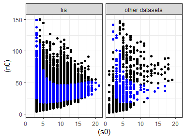

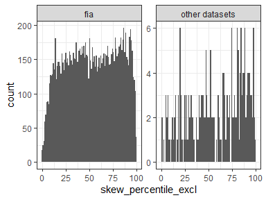

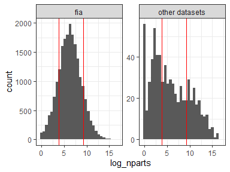

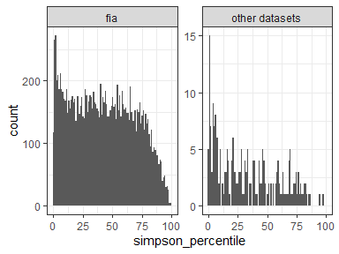

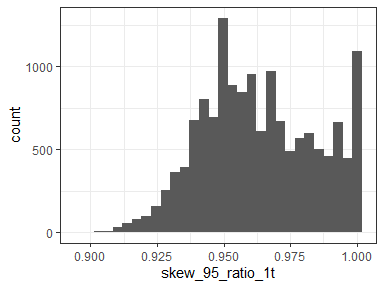

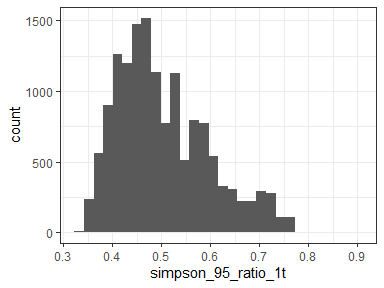

| fia_yn | prop_skew_high | nskew_sites |
| --- | --- | --- |
| fia | 0.0432552 | 14426 |
| other datasets | 0.0652174 | 230 |

| fia_yn | prop_even_low | neven_sites |
| --- | --- | --- |
| fia | 0.0792319 | 14426 |
| other datasets | 0.1845494 | 233 |

##### Big

And then anything over about 1500 elements:

- Effects for both skewness and evenness, which only get stronger as you increase the minimum
- Consistently more pronounced for other datasets for FIA, but the difference decreases as you increase the minimum

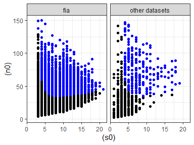

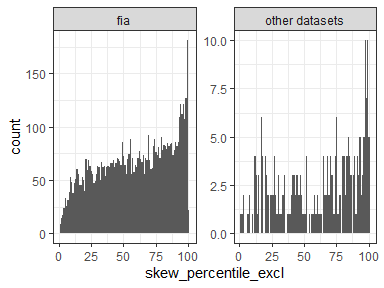

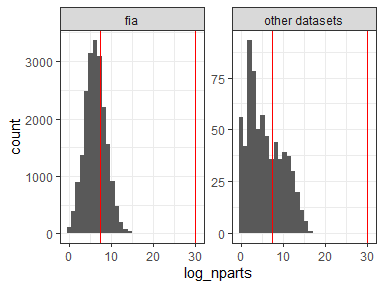

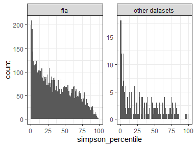

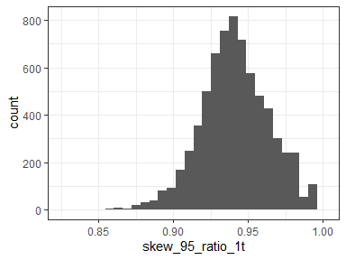

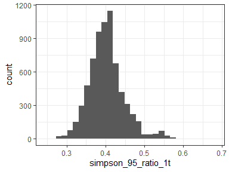

| fia_yn | prop_skew_high | nskew_sites |
| --- | --- | --- |
| fia | 0.0967742 | 6696 |
| other datasets | 0.1652542 | 236 |

| fia_yn | prop_even_low | neven_sites |
| --- | --- | --- |
| fia | 0.1375448 | 6696 |
| other datasets | 0.2838983 | 236 |

##### Really big

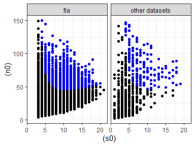

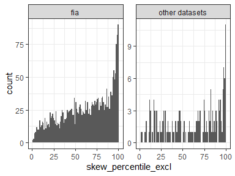

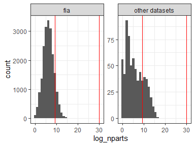

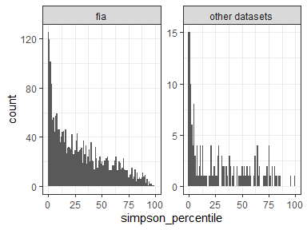

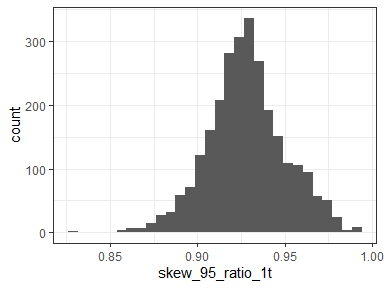

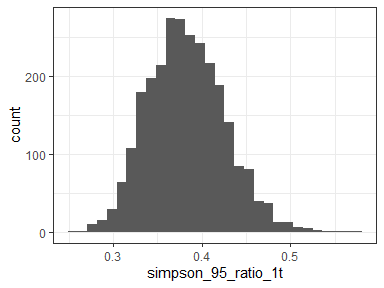

| fia_yn | prop_skew_high | nskew_sites |
| --- | --- | --- |
| fia | 0.1409396 | 2533 |
| other datasets | 0.1775148 | 169 |

| fia_yn | prop_even_low | neven_sites |
| --- | --- | --- |
| fia | 0.2021319 | 2533 |
| other datasets | 0.3195266 | 169 |